# Reproducible Research 1

Sebastian Restrepo Betancur

14/3/2022

# Loading and preprocessing the data

```r
informacion<-read.csv("activity.csv",header=TRUE)
```

# What is mean total number of steps taken per day?

## Calculate the total number of steps taken per day

```r
pasos<- aggregate(steps~date,informacion,sum)
pasos
```

```
##          date steps
## 1  2012-10-02   126
## 2  2012-10-03 11352
## 3  2012-10-04 12116
## 4  2012-10-05 13294
## 5  2012-10-06 15420
## 6  2012-10-07 11015
## 7  2012-10-09 12811
## 8  2012-10-10  9900
## 9  2012-10-11 10304
## 10 2012-10-12 17382
## 11 2012-10-13 12426
## 12 2012-10-14 15098
## 13 2012-10-15 10139
## 14 2012-10-16 15084
```

[output cut: 39 more lines]

### barplot:

A barplot (or barchart) is one of the most common types of graphic. It shows the relationship between a numeric and a categoric variable. Each entity of the categoric variable is represented as a bar. The size of the bar represents its numeric value.

### Hist:

A histogram is a graphical representation that organizes a group of data points into user-specified ranges. Similar in appearance to a bar graph, the histogram condenses a data series into an easily interpreted visual by taking many data points and grouping them into logical ranges or bins.

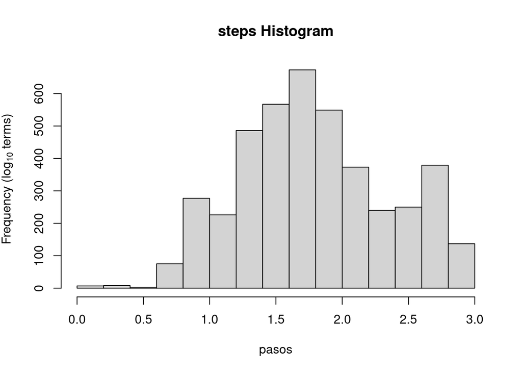

```r
hist(log10(informacion$steps),ylab= expression(paste("Frequency (",
            log[10]," terms)")),xlab="pasos",main="steps Histogram")
```

```r
medias<- aggregate(steps~date,informacion,mean)
medianas<-aggregate(steps~date,informacion,median)
colnames(medias)<- c("days","mean")
colnames(medianas)<- c("days","median")
juntos<- merge(medias,medianas)
juntos
```

```
##          days       mean median
## 1  2012-10-02  0.4375000      0
## 2  2012-10-03 39.4166667      0
## 3  2012-10-04 42.0694444      0
## 4  2012-10-05 46.1597222      0
## 5  2012-10-06 53.5416667      0
## 6  2012-10-07 38.2465278      0
## 7  2012-10-09 44.4826389      0
## 8  2012-10-10 34.3750000      0
## 9  2012-10-11 35.7777778      0
## 10 2012-10-12 60.3541667      0
## 11 2012-10-13 43.1458333      0
## 12 2012-10-14 52.4236111      0
## 13 2012-10-15 35.2048611      0
## 14 2012-10-16 52.3750000      0
```

[output cut: 39 more lines]

# Imputing missing values

```r
sum(is.na(informacion))
```

```
## [1] 2304
```

## Devise a strategy for filling in all of the missing values in the dataset:

```r
for (iter in 1:length(informacion$interval)){
  if(is.na(informacion[iter,1])){
    for(iter2 in 1:length(juntos$mean)){
      if(informacion[iter,2]==juntos[iter2,1]){
        informacion[iter,1]<-juntos[iter2,2]
        break
      }
      else{
        informacion[iter,1]<-mean(juntos$mean)
      }
    }
  }
}
```

## Create a new dataset that is equal to the original dataset but with the missing data filled in.

```r
head(informacion)
```

```
##     steps       date interval
## 1 37.3826 2012-10-01        0
## 2 37.3826 2012-10-01        5
## 3 37.3826 2012-10-01       10
## 4 37.3826 2012-10-01       15
## 5 37.3826 2012-10-01       20
## 6 37.3826 2012-10-01       25
```

## Make a histogram of the total number of steps taken each day and Calculate and report the mean and median total number of steps taken per day. Do these values differ from the estimates from the first part of the assignment? What is the impact of imputing missing data on the estimates of the total daily number of steps?

### the total number of steps taken each day

```r
totales<- aggregate(steps~date,informacion,sum)
totales
```

```
##          date    steps
## 1  2012-10-01 10766.19
## 2  2012-10-02   126.00
## 3  2012-10-03 11352.00
## 4  2012-10-04 12116.00
## 5  2012-10-05 13294.00
## 6  2012-10-06 15420.00
## 7  2012-10-07 11015.00
## 8  2012-10-08 10766.19
## 9  2012-10-09 12811.00
## 10 2012-10-10  9900.00
## 11 2012-10-11 10304.00
## 12 2012-10-12 17382.00
## 13 2012-10-13 12426.00
## 14 2012-10-14 15098.00
```

[output cut: 47 more lines]

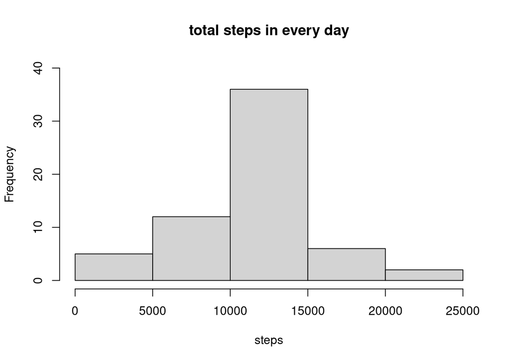

```r
hist(totales$steps,xlab="steps",main="total steps in every day",ylim = c(0,40))
```

the median 0 in some case is because there are some much cero’s values

```r
medias2<- aggregate(steps~date,informacion,mean)
medianas2<-aggregate(steps~date,informacion,median)
colnames(medias2)<- c("days","mean")
colnames(medianas2)<- c("days","median")
juntos2<- merge(medias2,medianas2)
juntos2
```

```
##          days       mean  median
## 1  2012-10-01 37.3825996 37.3826
## 2  2012-10-02  0.4375000  0.0000
## 3  2012-10-03 39.4166667  0.0000
## 4  2012-10-04 42.0694444  0.0000
## 5  2012-10-05 46.1597222  0.0000
## 6  2012-10-06 53.5416667  0.0000
## 7  2012-10-07 38.2465278  0.0000
## 8  2012-10-08 37.3825996 37.3826
## 9  2012-10-09 44.4826389  0.0000
## 10 2012-10-10 34.3750000  0.0000
## 11 2012-10-11 35.7777778  0.0000
## 12 2012-10-12 60.3541667  0.0000
## 13 2012-10-13 43.1458333  0.0000
## 14 2012-10-14 52.4236111  0.0000
```

[output cut: 47 more lines]

### What is the impact of imputing missing data on the estimates of the total daily number of steps?

It allows to improve the data a little and to be able to draw better conclusions

# What is the average daily activity pattern?

## Make a time series plot of the 5-minute interval (x-axis) and the average number of steps taken, averaged across all days (y-axis)

## Time Series plot of the average number of steps taken in a day.

Calculating the average steps taken for each 5-minute interval.

```r
PASOS <- aggregate(steps ~ interval, data = informacion, mean)
```

Converting ‘interval’ column data to a vailid date-time format.

```r
PASOS$time <- as.character(PASOS$interval)
for (i in 1:2){
  PASOS$time[i] <- as.character(paste0("0",PASOS$time[i]))
}
for (i in 1:12){
  PASOS$time[i] <- as.character(paste0("00",PASOS$time[i]))
}
for (i in 13:120){
  PASOS$time[i] <- as.character(paste0("0",PASOS$time[i]))
}
PASOS$time <- as.POSIXct(PASOS$time, format = "%H%M")
```

Now that we have the valid date-time format we can have a cleaner looking time-series plot, for the average 24-hour period.

[figure not shown]

```r
library(ggplot2)
library(lubridate)
library(scales)
plot2 <- ggplot(PASOS, aes(x = time, y = steps)) +
  geom_line(col = "red") +
  labs(title = "Time Series Plot", x = "Time of Day", y = "Steps") +
  scale_x_datetime(labels = date_format("%H:%M", tz = "MST"), date_breaks = "4 hours")
print(plot2)
```

## The 5-minute interval that on average contains the maximum number of steps

```r
PASOS[which.max(PASOS$steps),1:2]
```

```
##     interval    steps
## 104      835 184.0338
```

# Are there differences in activity patterns between weekdays and weekends?

```r
informacion_semanas <- informacion
informacion_semanas$days <- weekdays(as.Date(informacion_semanas$date))
informacion_semanas$weekday <- as.character(rep(0, times=17568))
for(x in 1:17568) {
    if(informacion_semanas[x, 4] %in% c("Saturday", "Sunday")) {
        informacion_semanas[x, 5] <- "weekend"
    } else {
        informacion_semanas[x, 5] <- "weekday"
    }
}
informacion_semanas$weekday <- factor(informacion_semanas$weekday)
head(informacion_semanas)
```

```
##     steps       date interval   days weekday
## 1 37.3826 2012-10-01        0 Monday weekday
## 2 37.3826 2012-10-01        5 Monday weekday
## 3 37.3826 2012-10-01       10 Monday weekday
## 4 37.3826 2012-10-01       15 Monday weekday
## 5 37.3826 2012-10-01       20 Monday weekday
## 6 37.3826 2012-10-01       25 Monday weekday
```

To compare the weekday and weekend data, and create two plots of the average number of steps taken per interval, the data has to be split into two groups of weekday/weekend data, using the newly created variable.

```r
weekdayData <- informacion_semanas[informacion_semanas$weekday=="weekday", ]
weekendData <- informacion_semanas[informacion_semanas$weekday=="weekend", ]
```

Next, the average number of steps per interval is calculated, much like it has been done in previous questions.

```r
weekdayMean <- aggregate(steps ~ interval, weekdayData, mean)
weekendMean <- aggregate(steps ~ interval, weekendData, mean)
```

Finally the panel plot is created. The x axis indicates each 5 minute interval, and the y axis shows the average number of steps taken. The two plots are divided into weekday, and weekend data.

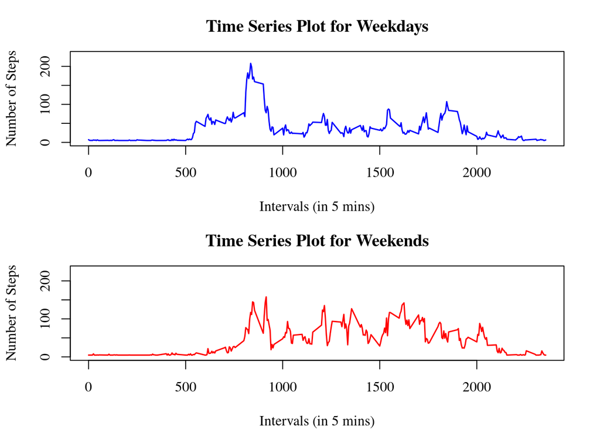

```r
par(mfrow=c(2, 1), mar=c(4, 4.1, 3, 2.1))
plot(weekdayMean$interval, weekdayMean$steps, type="l",
     main="Time Series Plot for Weekdays",
     xlab="Intervals (in 5 mins)", ylab="Number of Steps", family="serif",
     col="blue", lwd=1.5, ylim=c(0, 230))
plot(weekendMean$interval, weekendMean$steps, type="l",
     main="Time Series Plot for Weekends",
     xlab="Intervals (in 5 mins)", ylab="Number of Steps", family="serif",
     col="red", lwd=1.5, ylim=c(0, 230))
```